# class notes11.12

Author

Mio Takata

```r
library(tidyverse)
library(readxl)
trout = read_excel("trout.xlsx")
```

Do trout at the difference locations have different hemoglobin levels?

$H_0$: the *population* means of “Hemo” are the same for all locations. $H_a$: the population means of “Hemo” are not the same for all locations.

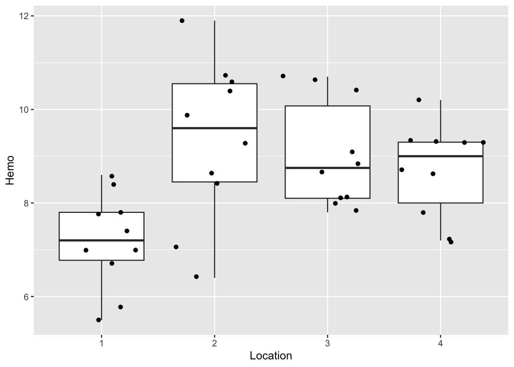

```r
trout <- trout %>%
  mutate(Location = as.factor(Location)) # making numbers into descrete variable

ggplot(trout, aes(x = Location, y = Hemo))+
  geom_boxplot()+
  geom_jitter()
```

Let’s run the test.

```r
model<- aov(Hemo ~ Location, data = trout)
summary(model)
```

```
            Df Sum Sq Mean Sq F value  Pr(>F)
Location     3  26.80   8.934   5.696 0.00268 **
Residuals   36  56.47   1.569
---
Signif. codes:  0 '***' 0.001 '**' 0.01 '*' 0.05 '.' 0.1 ' ' 1
```

is himo explained at all from location low p value is against the null hypothesis of hemo is not explained by the location possible? sure but plausible, maybe not

The tiny p value indicates good evience against the null, we can conclude that `Location` does give information about `Hemo`. Trout at difference locations do seems to have difference `Hemo`level

This does *not* say anything about which groups might be different. To do that, we need to do some pairwise comparisons.However, if we just run all pf those directlym there is a high probability of getting at least one small p-value just by chance, even if there really isn’t a difference

## The Tukey post-hoc test

To correctly follow up a positive ANOVA, use a *Tukey Honest Standard Differences Test* which does a pairwise comparison for each pair of groups, correcting for the multiple tests/

```r
TukeyHSD(model)
```

```
  Tukey multiple comparisons of means
    95% family-wise confidence level

Fit: aov(formula = Hemo ~ Location, data = trout)

$Location
     diff         lwr       upr     p adj
2-1  2.13  0.62148556 3.6385144 0.0028743
3-1  1.83  0.32148556 3.3385144 0.0122308
4-1  1.49 -0.01851444 2.9985144 0.0539172
3-2 -0.30 -1.80851444 1.2085144 0.9497752
4-2 -0.64 -2.14851444 0.8685144 0.6660242
4-3 -0.34 -1.84851444 1.1685144 0.9291864
```

# conclusion from the Tukey test

*95%*family-wise confidence level means that there is a 5% of false positive.

## Example: penguins

$H_0$: bill length is the same for all three species. $H_1$: bill length is not the same.

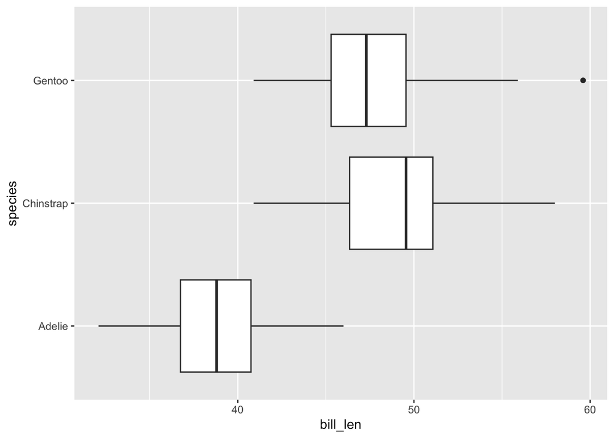

```r
ggplot(penguins, aes(x = bill_len, y = species))+
  geom_boxplot()
```

```r
model_2<- aov(bill_len ~ species, data = penguins)
summary(model_2)
```

```
             Df Sum Sq Mean Sq F value Pr(>F)
species       2   7194    3597   410.6 <2e-16 ***
Residuals   339   2970       9
---
Signif. codes:  0 '***' 0.001 '**' 0.01 '*' 0.05 '.' 0.1 ' ' 1
2 observations deleted due to missingness
```

```r
TukeyHSD(model_2)
```

```
  Tukey multiple comparisons of means
    95% family-wise confidence level

Fit: aov(formula = bill_len ~ species, data = penguins)

$species
                      diff       lwr        upr     p adj
Chinstrap-Adelie 10.042433  9.024859 11.0600064 0.0000000
Gentoo-Adelie     8.713487  7.867194  9.5597807 0.0000000
Gentoo-Chinstrap -1.328945 -2.381868 -0.2760231 0.0088993
```